# BS1811-1516 Financial Analytics Assignment 1

C.K. Poon, Jin Lee, Chan Baik, Yujia Ren, Siang Lau

30 May 2016

# 1 Introduction

# 2 Data Preparation

**Step 1** - Load the data

```r
#Reading data
```

# 3 CVA pricing

## 3.2 Part ii

Implement a Geometric Brownian Motion (GBM) for the Equity underlying process

## 3.5 Part v

Now add a second option trade in the portfolio.

# 4 Option pricing

## 4.1 Definition of Barrier Options

Barrier options are pathdependent options, with payoffs that depend on the price of the underlying asset at expiration and whether or not the asset price crosses a barrier during the life of the option [1]. There are two categories or types of Barrier options: “knock-in” and “knock-out”. “Knock-in” or “in” options are paid for up front, but you do not receive the option until the asset price crosses the barrier. “Knock-out” or “out” options come into existence on the issue date but becomes worthless if the asset price hits the barrier before the expiration date. If the option is a knock-in (knock-out), a predetermined cash rebate may be paid at expiration if the option has not been knocked in (knocked-out) during its lifetime. [1]

According to when options can be exercised, they are classified into mainly three groups; European, Bermudan and American Options. American options can be exercised at any time up to the expiration date, whereas European options can be exercised only on the expiration date itself. Bermudan options are similar in style to American options regarding the possibility of early exercise. However, the difference is the fact that a Bermudan option has predetermined discrete exercise dates [2].

**Down-and-in call option**

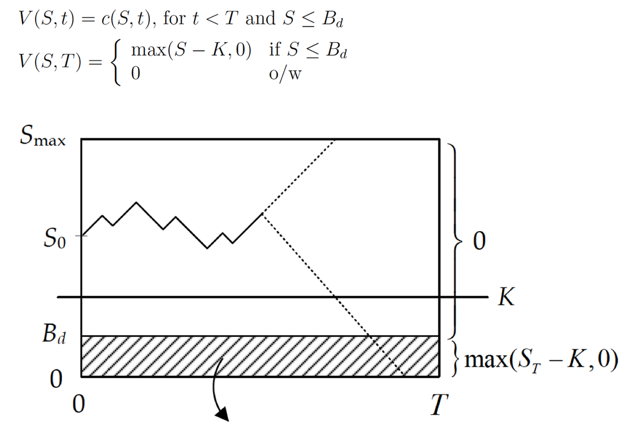

Figure 1: Down-and-in Barrier Options [3]

```r
include_graphics("./Siang/downin.png")
```

**Down-and-out call option**

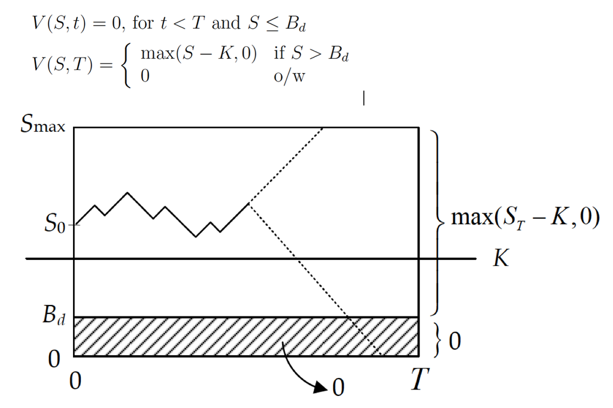

Figure 2: Down-and-out Barrier Options [3]

```r
include_graphics("./Siang/downout.png")
```

**In-out parity**

European vanilla option = European knock-out option + European knock-in option [3]

- Suppose an investor holds both a knock-out option and a knock-in option. If the stock price never touches the barrier, the knock-out option will provide the same payoff as that of a vanilla option at maturity. When the stock price touches the barrier, the knock-out option becomes worthless and the knock-in option are enabled and providing the same payoff as that of a vanilla option at maturity.
- Since the combined payoff of a knock-out option and a knock-in option are the same as that of a vanilla option at maturity, their values today should be equal. This result is termed as “in-out parity.”
- Alternative method to price knock-in options: Since it needs more computational effort to price a knock-in option, it is possible to price a knock-out option with the same barrier first, and then apply the in-out parity to derive the value of the knock-in option.

## 4.2 Method 1 - Monte Carlo Method

### 4.2.1 Analysis

The procedures of applying monte carlo method on barrier options pricing is summarised below:

- Step 1 - Simulate random paths with GBM process for the spot value until maturity T.
- Step 2 - Decide whether each path is knocked in or out and thus determine the final payoff of each path.
- Step 3 - Calculate the payoff at maturity.
- Step 4 - Discount all future payoff distribution of values to t0.
- Step 5 - Calculate the mean of discounted payoff distribution.

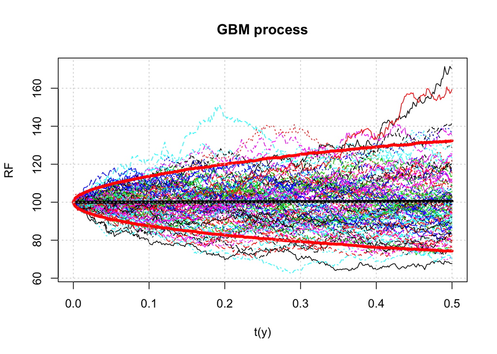

```r
#########################################
# Step 0 - Define initial/valuation input
#########################################
#Set seed for random numbers
set.seed(12345)
# Simulation period
T<-0.5
# Step in y with 360 day-count convention
tStep<-1/(360*2)
# Scenarios
nPaths<-10000
#Evaluation times in units of year
time<-seq(0,T,tStep)

# Parameters (S0, vola, drift)
start_value<-100
# yearly vola
vola<-0.25
# Annualized rate of interest
r <-0.01
# Annualized cost-of-carry rate
b <-0.01
# Barrier Value
H <- 75
# yearly drift
drift<-r
# Strike price
strike<-90


#######################################################################################
# Step 1 - Simulate random paths with GBM process for the spot value until maturity T.
#######################################################################################
#Definition of the RF box
RF_GBM<-matrix(0,nrow=nPaths,ncol=length(time))

#We generate random numbers N(0,1)
#Always better to generate the innovations in a vectorial fashion and then "distribute" them
pass_rand<-rnorm(nPaths*(length(time)-1))
pass_rand<-matrix(pass_rand,nrow=nPaths,ncol=(length(time)-1))
pass_rand<-scale(pass_rand,center = TRUE,scale = TRUE)
#Adding the starting value
pass_rand<-cbind(rep(0,nPaths),pass_rand)
#Accrueting the innovations
pass_rand<-t(apply(pass_rand,1,cumsum))
#drift_matrix: x=x0*exp(mu*t-vola^2*t/2)*exp(vola*N(0,1)*sqrt(t))
pass_drift<-matrix(rep(exp(-0.5*time*vola^2+time*drift),nPaths),nrow=nPaths,ncol=length(time),
                   byrow=TRUE)
#Generation of the paths (scaling the random component by tStep)
RF_GBM<-start_value*exp(pass_rand*vola*sqrt(tStep))*pass_drift
rownames(RF_GBM)<-paste("history",as.character(seq(1,nPaths,1)),sep="")
colnames(RF_GBM)<-paste(as.character(time),"y",sep="")

par(mfrow=c(1,1))
matplot(time,t(RF_GBM)[,1:100],type="l",xlab="t(y)",ylab="RF",main="GBM process")
points(time,apply(t(RF_GBM),1,mean),type="l",col=1,lwd=4)
points(time,apply(t(RF_GBM),1,quantile,0.05),type="l",col=2,lwd=4)
points(time,apply(t(RF_GBM),1,quantile,0.95),type="l",col=2,lwd=4)
grid()
```

```r
#########################################################
# Step 2 - Decide whether each path is knocked in or out
# and thus determine the final payoff of each path
#########################################################
#Vanilla Opiton
RF_GBM_vanilla<-RF_GBM

#Exotic Option - down-and-in
# Any prices fall below 75 before the maturity will trigger knocking-in of option
# Once it is in, it's in for good.
RF_GBM_di<-RF_GBM[,ncol(RF_GBM)]*(apply(RF_GBM,1,min) < H)

# Exotic Option - down-and-out
# Any prices fall below 75 before the maturity will trigger knocking-out of option
# Once it is out, it's out for good
RF_GBM_do<-RF_GBM[,ncol(RF_GBM)]*(apply(RF_GBM,1,min) >= H)


###################################################################
# Step 3 - calculate the payoff at maturity
###################################################################
#Vanilla Opiton
payoff_vanilla <- pmax(RF_GBM_vanilla[,ncol(RF_GBM_vanilla)] - strike,0)

#Vanilla Opiton
payoff_di<-pmax(RF_GBM[,ncol(RF_GBM)] - strike,0) * (apply(RF_GBM,1,min) < H)

#Vanilla Opiton
payoff_do<-pmax(RF_GBM[,ncol(RF_GBM)] - strike,0) * (apply(RF_GBM,1,min) >= H)

###################################################################
# Step 4 - Discount all future payoff distribution of values to t0.
###################################################################
#Vanilla Opiton
discounted_payoff_vanilla <- exp(-r*T)*payoff_vanilla

#Exotic Option - down-and-in
discounted_payoff_di <- exp(-r*T)*payoff_di

#Exotic Option - down-and-out
discounted_payoff_do <- exp(-r*T)*payoff_do

################################################################
# Step 5 - Calculate the mean of discounted payoff distribution.
################################################################
#Vanilla Opiton
price_vanilla <- mean(discounted_payoff_vanilla)

#Exotic Option - down-and-in
price_di <- mean(discounted_payoff_di)

#Exotic Option - down-and-out
price_do <- mean(discounted_payoff_do)
```

### 4.2.2 Results

The payoffs at maturity and prices of options are shown below.

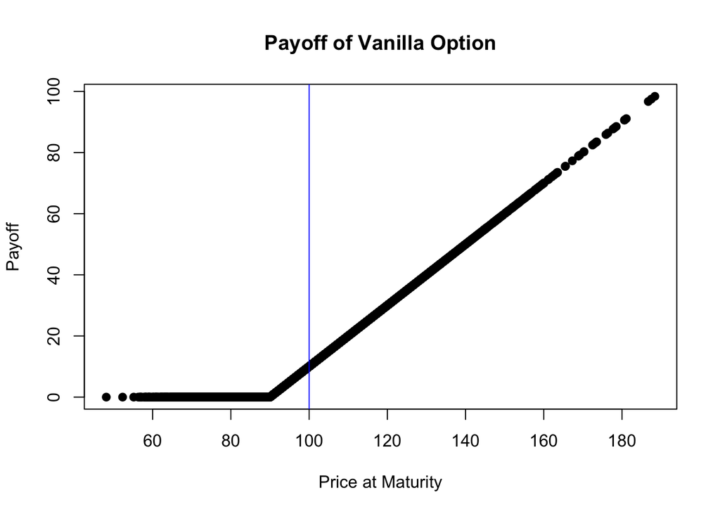

```r
# Check: vanilla option price = knock-out option price + knock-in option price
#Vanilla Option
plot(RF_GBM_vanilla[,ncol(RF_GBM_vanilla)],payoff_vanilla,pch=19,main="Payoff of Vanilla Option", xlab="Price at Maturity", ylab="Payoff")
abline(v=start_value,col=4)
```

```r
print(paste0("The price of vanilla option is ", price_vanilla))
```

```
## [1] "The price of vanilla option is 13.2164280759335"
```

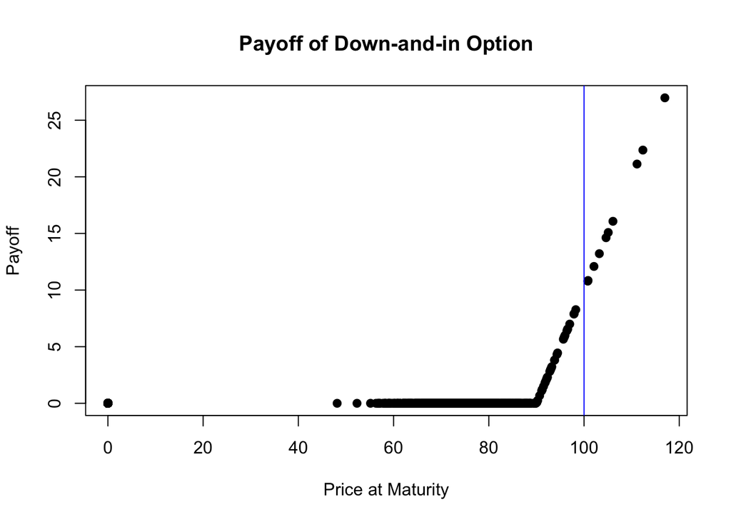

```r
#Down-and-in Option   #here is the prolem, RF_GBM_di has been removed
plot(RF_GBM_di,payoff_di,pch=19,main="Payoff of Down-and-in Option", xlab="Price at Maturity", ylab="Payoff")
abline(v=start_value,col=4)
```

```r
print(paste0("The price of exotic down-and-in option is ", price_di))
```

```
## [1] "The price of exotic down-and-in option is 0.0286069347124088"
```

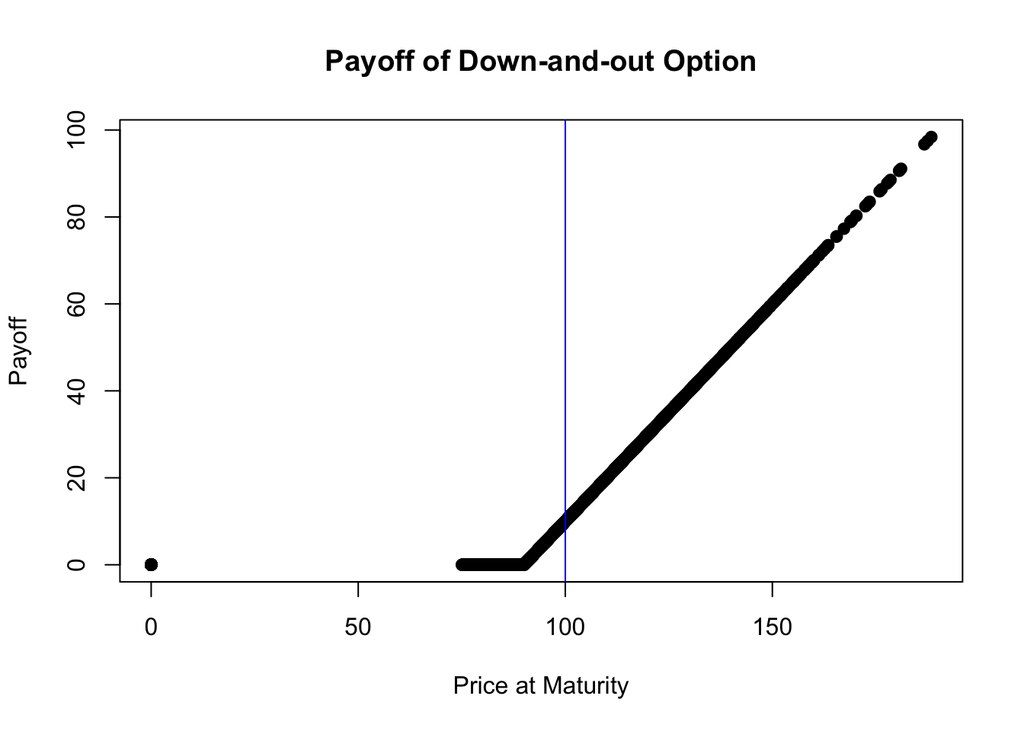

```r
#Down-and-out Option
plot(RF_GBM_do,payoff_do,pch=19,main="Payoff of Down-and-out Option", xlab="Price at Maturity", ylab="Payoff")
abline(v=start_value,col=4)
```

```r
print(paste0("The price of exotic down-and-out option is ", price_do))
```

```
## [1] "The price of exotic down-and-out option is 13.1878211412211"
```

## 4.3 Method 2 - R package fExoticOptions

The definitions of the variables required in the StandardBarrierOption function are explained below [1].

- S is the asset price, a numeric value
- X is the exercise price, a numeric value
- H is the barrier value, a numeric value
- Time is the time to maturity measured in years, a numeric value; e.g. 0.5 means 6 months
- r is the annualized rate of interest, a numeric value; e.g. 0.25 means 25% pa
- b is the the annualized cost-of-carry rate, a numeric value; e.g. 0.1 means 10% pa.
- sigma is the annualized volatility of the underlying security, a numeric value; e.g. 0.3 means 30% volatility pa
- K for an “In”-Barrier a prespecified cash rebate which is paid out at option expiration if the option has not been knocked in during its lifetime,for an “Out”-Barrier a prespecified cash rebate which is paid out at option expiration if the option has not been knocked out before its lifetime, a numerical value

### 4.3.1 Vanilla option

```r
GBSOption(TypeFlag="c",S=100,X=90,Time=0.5,r=0.01,b=0.01,sigma=0.25)
```

```
##
## Title:
##  Black Scholes Option Valuation
##
## Call:
##  GBSOption(TypeFlag = "c", S = 100, X = 90, Time = 0.5, r = 0.01,
##      b = 0.01, sigma = 0.25)
##
## Parameters:
##           Value:
##  TypeFlag c
##  S        100
##  X        90
##  Time     0.5
##  r        0.01
##  b        0.01
##  sigma    0.25
##
## Option Price:
##  13.15496
##
## Description:
##  Wed Jun  8 18:29:16 2016
```

The price of the vanilla call option is 13.15496 where a prespecified cash rebate is assumed to be 0.

### 4.3.2 Down-and-in call option

```r
StandardBarrierOption(TypeFlag = "cdi", S = 100, X = 90,H = 75, K = 0, Time = 0.5, r = 0.01, b = 0.01, sigma = 0.25)
```

```
##
## Title:
##  Standard Barrier Option
##
## Call:
##  StandardBarrierOption(TypeFlag = "cdi", S = 100, X = 90, H = 75,
##      K = 0, Time = 0.5, r = 0.01, b = 0.01, sigma = 0.25)
##
## Parameters:
##           Value:
##  TypeFlag cdi
##  S        100
##  X        90
##  H        75
##  K        0
##  Time     0.5
##  r        0.01
##  b        0.01
##  sigma    0.25
##
## Option Price:
##  0.02019197
##
## Description:
##  Wed Jun  8 18:29:16 2016
```

The price of the down-and-in call option is 0.0202 where a prespecified cash rebate is assumed to be 0.

### 4.3.3 Down-and-out call option

```r
StandardBarrierOption(TypeFlag = "cdo", S = 100, X = 90,H = 75, K = 0, Time = 0.5, r=0.01, b = 0.01, sigma = 0.25)
```

```
##
## Title:
##  Standard Barrier Option
##
## Call:
##  StandardBarrierOption(TypeFlag = "cdo", S = 100, X = 90, H = 75,
##      K = 0, Time = 0.5, r = 0.01, b = 0.01, sigma = 0.25)
##
## Parameters:
##           Value:
##  TypeFlag cdo
##  S        100
##  X        90
##  H        75
##  K        0
##  Time     0.5
##  r        0.01
##  b        0.01
##  sigma    0.25
##
## Option Price:
##  13.13477
##
## Description:
##  Wed Jun  8 18:29:16 2016
```

The price of the down-and-out call option is 13.13477 where a prespecified cash rebate is assumed to be 0.

## 4.4 Evaluation of methods

**Question:** StandardBarrierOption assumes a continuous monitoring of the barrier instead of the discrete one (i.e. the time grid) of your Monte Carlo. Does this affect your Monte Carlo price? Is the difference between the Monte Carlo prices and the closed form solution affected by both Monte Carlo noise and the type of the barrier monitoring? Please comment.

In simulation, due to the inability of Monte Carlo to simulate in continuous time, an option is priced under the assumption that it has Bermudan style, and thus only discrete exercise opportunities exist. So for example, if an American option is exercisable at any time t where 0 ≤ t ≤ T , we restrict the option such that it can be exercised only at a fixed set of exercise opportunities 0 < t1 < t2 < . . . < td, where d is the number of exercisable time steps.

The monte carlo methods monitor the barrier at half-day basis in our case while the standard barrier option is based on continuous monitoring. The frequency /sequence used to generate the random path for Monte Carlo simulation will affect the Monte Carlo price. For example, discrete monitoring compare the price and barrier at specific time. It fails to recognise P<H between to monitoring points for down-out options. This is not the case for the continuous monitoring. The difference of monitoring will affect the payoff of barrier option ( continuous monitoring is more likely to have worthless payoff). The price of two methods will only coverage when the frequency of monte carlo is high enough, but with high frequency, the dimension would be too large to compute. We do a half-day monitoring in our case giving a 361 x 10000 matrix; if monitor hourly, we are going to deal with a 4321 x 10000 matrix; if by minute or seconds, computational complexity of trying to make discrete monitoring as close to continuous could be very high. Based on Broadie et al, it is possible to use the continuous barrier formula to price the discrete barrier option with high accuracy by shifting barrier away from the. underlying. In terms of Monte Carlo noises, although, multiple random paths may yield slight different results, but since we are going to aggregate the results from different paths by taking average, the noises becomes a non-factor with large simulation by the rule of large samples. Therefore, monte Carlo noise is not a major factor of the difference in prices from two methods if the sample size generated by Monte Carlo is sufficient large.

# 5 Backtesting

## 5.1 Part 1

## 5.2 Part 2

## 5.3 Part 3

# 6 Reference

- [1] “Options Basics: What Are Options? | Investopedia.” Investopedia. Ed. Staff .. Investopedia. Investopedia, 02 Dec. 2003. Web. 02 June 2016.
- [2] Longstaff, F A and Schwartz, E S, 2001, ”Valuing American Options by Simulation: A Simple Least-Squares Approach”, Review of Financial Studies, Vol. 14, No. 1, pp. 113-147.
- [3] Birge, John R., and Vadim Linetsky. Financial Engineering. Amsterdam: North-Holland, 2008. Print.